# Extração de Conhecimento de Dados Biológicos - Trabalho 1

Diogo Barreira, Gonçalo Gomes, José Campos

2026-04-30

# 1. Introdução

O crescimento exponencial de dados biológicos, impulsionado por tecnologias de sequenciação de nova geração (NGS), tem permitido estudar sistemas biológicos a uma escala sem precedentes. Entre estes, os dados de expressão genética obtidos por RNA sequencing (RNA-seq) são particularmente relevantes, uma vez que permitem quantificar os níveis de atividade dos genes em diferentes condições biológicas.

Neste trabalho, foi analisado um conjunto de dados de expressão genética relativo ao carcinoma da tiroide (THCA), proveniente de bases de dados públicas como o The Cancer Genome Atlas (TCGA). Este conjunto de dados contém medições de expressão para dezenas de milhares de genes em centenas de amostras, bem como metadados associados que descrevem características clínicas e fenotípicas das mesmas.

O principal objetivo deste trabalho consiste na exploração e análise destes dados, incluindo a identificação de padrões relevantes, a redução da dimensionalidade, a aplicação de métodos de clustering e, finalmente, a construção de modelos preditivos capazes de classificar amostras com base nos seus perfis de expressão genética.

Para tal, foram utilizadas ferramentas do ambiente R, nomeadamente estruturas de dados especializadas como o `SummarizedExperiment`, bem como métodos estatísticos e de aprendizagem automática adequados à análise de dados ómicos de alta dimensão.

```r
dados <- readRDS("dados_thca.rds")
dados
```

```
## class: RangedSummarizedExperiment
## dim: 60660 564
## metadata(1): data_release
## assays(6): unstranded stranded_first ... fpkm_unstrand fpkm_uq_unstrand
## rownames(60660): ENSG00000000003.15 ENSG00000000005.6 ...
##   ENSG00000288674.1 ENSG00000288675.1
## rowData names(10): source type ... hgnc_id havana_gene
## colnames(564): TCGA-DJ-A2Q6-01A-11R-A18C-07
##   TCGA-FK-A3SE-01A-11R-A22L-07 ... TCGA-DJ-A2PX-01A-11R-A18C-07
##   TCGA-EL-A3ZS-01A-12R-A23N-07
## colData names(242): barcode patient ... paper_TERT_AC paper_TERT_Q
```

```r
class(dados)
```

```
## [1] "RangedSummarizedExperiment"
## attr(,"package")
## [1] "SummarizedExperiment"
```

O conjunto de dados encontra-se armazenado num objeto do tipo RangedSummarizedExperiment, que integra diferentes componentes relevantes para a análise de dados de RNA-seq.

Para as análises subsequentes, foi necessário extrair a matriz de expressão genética e os metadados associados às amostras. Foi selecionada a matriz de expressão FPKM-UQ (unstranded), uma vez que corresponde a uma medida normalizada adequada para comparação entre amostras.

```r
library(SummarizedExperiment)

expr <- assay(dados, "fpkm_uq_unstrand")
meta <- as.data.frame(colData(dados))

dim(expr)
```

```
## [1] 60660   564
```

```r
dim(meta)
```

```
## [1] 564 242
```

A matriz expr contém os níveis de expressão dos genes nas diferentes amostras, enquanto o objeto meta armazena informação clínica e experimental relevante que será utilizada nas etapas posteriores da análise.

## 2.2 Dimensões dos dados

Após a extração da matriz de expressão e dos metadados, verificaram-se as dimensões das estruturas obtidas.

A matriz de expressão apresenta 60660 genes (linhas) e 564 amostras (colunas), enquanto os metadados incluem informação correspondente às mesmas 564 amostras, descritas por 242 variáveis clínicas e experimentais.

Esta configuração é característica de dados ómicos, nos quais o número de variáveis (genes) é muito superior ao número de observações (amostras), o que implica a necessidade de técnicas de redução de dimensionalidade e seleção de características nas etapas seguintes da análise.

## 2.3 Identificação da variável de interesse

```r
unique(meta$sample_type)
```

```
## [1] "Primary Tumor"       "Solid Tissue Normal"
```

De forma a definir o problema de análise, foi selecionada uma variável de interesse que permite distinguir entre diferentes tipos de amostras.

Neste trabalho, o objetivo consiste em classificar as amostras em função da sua condição biológica, nomeadamente entre tecido tumoral e tecido normal. Para tal, foi utilizada a variável `sample_type`, presente nos metadados, que descreve o tipo de cada amostra.

A análise dos valores desta variável revelou a existência de duas categorias principais: *Primary Tumor* e *Solid Tissue Normal*, correspondendo, respetivamente, a amostras tumorais e amostras de tecido normal. Esta distinção permite definir um problema de classificação binária, que será explorado nas etapas seguintes.

# 3. Análise Exploratória dos Dados

Nesta secção é realizada uma análise exploratória dos dados de expressão genética, com o objetivo de compreender a sua estrutura, distribuição e possíveis padrões associados às diferentes condições biológicas.

A exploração dos dados permite identificar características relevantes, como a presença de outliers, diferenças entre grupos e a necessidade de transformações adicionais, constituindo um passo fundamental antes da aplicação de métodos mais avançados.

## 3.1 Distribuição dos dados

De forma a analisar a distribuição dos valores de expressão genética, foi selecionado um subconjunto de genes com maior variabilidade.

Dado o elevado número de genes presentes no conjunto de dados, a utilização de todos os valores tornaria a representação gráfica pouco legível. Assim, foram selecionados os genes com maior variância, por forma a obter uma visualização mais informativa e representativa da dispersão dos dados.

Os boxplots permitem observar a distribuição dos níveis de expressão, bem como identificar possíveis valores extremos e diferenças na variabilidade entre genes.

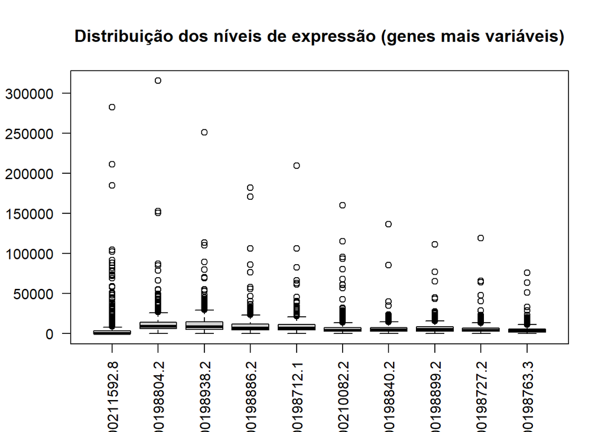

```r
vars <- apply(expr, 1, var)

genes_sample <- order(vars, decreasing = TRUE)[1:10]

boxplot(t(expr[genes_sample, ]),
        main = "Distribuição dos níveis de expressão (genes mais variáveis)",
        las = 2)
```

A análise dos boxplots revela que os dados de expressão genética apresentam distribuições fortemente assimétricas, com a maioria dos valores concentrados em níveis baixos e a presença de caudas longas associadas a valores elevados.

Observa-se ainda a existência de numerosos valores extremos (outliers), indicando uma elevada variabilidade nos níveis de expressão de determinados genes.

Estas características são típicas de dados de RNA-seq e evidenciam a necessidade de aplicar transformações adicionais aos dados, de forma a reduzir a assimetria e estabilizar a variância, facilitando as análises subsequentes.

## 3.2 Transformação dos dados

A análise exploratória revelou que os dados de expressão genética apresentam distribuições assimétricas e elevada variabilidade, características típicas de dados de RNA-seq.

De forma a facilitar a análise e interpretação dos dados, foi aplicada uma transformação logarítmica aos valores de expressão.

```r
expr_log <- log2(expr)
```

Esta transformação permite reduzir o impacto de valores extremos e tornar a distribuição dos dados mais equilibrada, facilitando a aplicação de métodos de análise subsequentes.

## 3.3 Comparação entre grupos

De forma a avaliar possíveis diferenças entre amostras tumorais e normais, foi utilizada a variável sample_type, previamente identificada nos metadados.

Inicialmente, foi analisada a distribuição das amostras por grupo.

```r
table(meta$sample_type)
```

```
##
##       Primary Tumor Solid Tissue Normal
##                 505                  59
```

Para ilustrar possíveis diferenças nos níveis de expressão, foram analisados alguns genes com elevada variabilidade, comparando os seus valores entre os dois grupos.

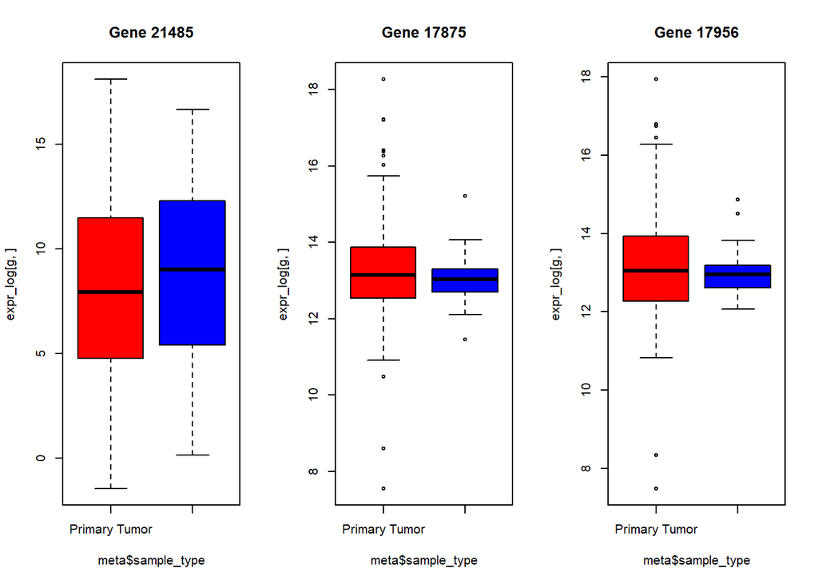

```r
genes_exemplo <- genes_sample[1:3]

par(mfrow = c(1,3))

for (g in genes_exemplo) {
  boxplot(expr_log[g, ] ~ meta$sample_type,
          col = c("red", "blue"),
          main = paste("Gene", g))
}
```

A análise dos gráficos revela a existência de diferenças nos níveis de expressão entre amostras tumorais e normais para alguns dos genes considerados. No entanto, observa-se também uma sobreposição significativa entre os grupos, indicando que a separação entre classes não é clara quando se considera apenas um número reduzido de genes isoladamente.

Estes resultados sugerem a presença de padrões biológicos distintos entre os grupos, motivando a realização de análises mais aprofundadas, nomeadamente a identificação sistemática de genes diferencialmente expressos.

## 3.4 Análise de Componentes Principais (PCA)

De forma a explorar a estrutura global dos dados, foi aplicada uma análise de componentes principais (PCA), uma técnica de redução de dimensionalidade que permite representar os dados num espaço de menor dimensão.

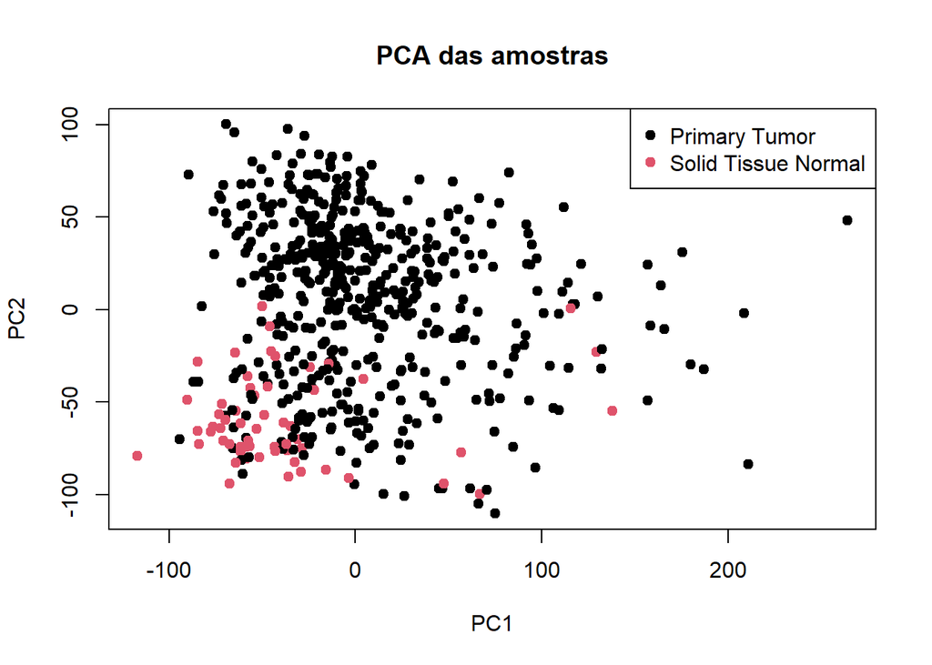

```r
expr_clean <- expr_log
expr_clean[!is.finite(expr_clean)] <- NA

expr_clean <- expr_clean[complete.cases(expr_clean), ]

vars <- apply(expr_clean, 1, var)
expr_clean <- expr_clean[vars > 0, ]

pca <- prcomp(t(expr_clean), scale = TRUE)

plot(pca$x[,1], pca$x[,2],
     col = as.factor(meta$sample_type),
     pch = 19,
     xlab = "PC1",
     ylab = "PC2",
     main = "PCA das amostras")

legend("topright",
       legend = levels(as.factor(meta$sample_type)),
       col = 1:2,
       pch = 19)
```

```r
var_explained <- (pca$sdev)^2
var_explained <- var_explained / sum(var_explained)

pca_df <- data.frame(
  PC = paste0("PC", 1:10),
  Variance = round(var_explained[1:10], 3),
  Cumulative = round(cumsum(var_explained[1:10]), 3)
)

pca_df
```

```
##      PC Variance Cumulative
## 1   PC1    0.175      0.175
## 2   PC2    0.142      0.317
## 3   PC3    0.075      0.392
## 4   PC4    0.054      0.446
## 5   PC5    0.035      0.481
## 6   PC6    0.031      0.513
## 7   PC7    0.026      0.539
## 8   PC8    0.023      0.562
## 9   PC9    0.018      0.580
## 10 PC10    0.017      0.597
```

A análise de componentes principais (PCA) permite observar a estrutura global dos dados de expressão genética, bem como a relação entre amostras tumorais e normais.

Os resultados indicam que o primeiro componente principal (PC1) explica aproximadamente 17.5% da variabilidade total dos dados, enquanto o segundo componente (PC2) explica cerca de 14.2%. Em conjunto, os dois primeiros componentes capturam cerca de 31.7% da variabilidade, evidenciando que uma parte significativa da informação pode ser representada em duas dimensões.

A projeção das amostras no espaço definido pelos dois primeiros componentes revela uma tendência de separação entre amostras tumorais e normais, particularmente ao longo do segundo componente principal (PC2). As amostras de tecido normal encontram-se mais concentradas numa região específica do gráfico, enquanto as amostras tumorais apresentam uma maior dispersão.

No entanto, observa-se também alguma sobreposição entre os grupos, indicando que a separação entre classes não é completamente linear quando reduzida a apenas dois componentes. Esta sobreposição sugere que a distinção entre amostras tumorais e normais depende de múltiplas dimensões do espaço de dados.

Adicionalmente, a maior dispersão das amostras tumorais sugere uma maior heterogeneidade neste grupo, refletindo a variabilidade biológica associada ao desenvolvimento tumoral.

Estes resultados indicam que os dados de expressão genética contêm informação relevante para distinguir entre os grupos, justificando a aplicação de métodos de análise mais avançados nas secções seguintes.

# 4. Análise de Expressão Diferencial

Nesta secção é realizada uma análise de expressão diferencial com o objetivo de identificar genes cujos níveis de expressão diferem significativamente entre amostras tumorais e normais.

Para tal, foi utilizado o package DESeq2, amplamente utilizado na análise de dados de RNA-seq, que modela os dados de contagem e permite identificar genes diferencialmente expressos de forma estatisticamente robusta.

```r
assayNames(dados)
```

```
## [1] "unstranded"       "stranded_first"   "stranded_second"  "tpm_unstrand"
## [5] "fpkm_unstrand"    "fpkm_uq_unstrand"
```

## 4.1 Preparação dos dados

Para a análise de expressão diferencial, foram utilizados os dados de contagem (*counts*), uma vez que métodos como o DESeq2 assumem distribuições discretas adequadas a este tipo de dados.

Assim, foi selecionada a matriz de contagens `unstranded`, correspondente aos valores brutos de expressão genética.

```r
counts <- assay(dados, "unstranded")
```

## 4.2 Execução da análise de expressão diferencial

A análise de expressão diferencial foi realizada utilizando o package DESeq2. Este método permite modelar os dados de contagem e identificar genes com diferenças estatisticamente significativas entre condições experimentais.

Foi criado um objeto DESeqDataSet, considerando como variável de interesse o tipo de amostra (`sample_type`), distinguindo entre tecido tumoral e normal.

```r
library(DESeq2)

dds <- DESeqDataSetFromMatrix(
  countData = counts,
  colData = meta,
  design = ~ sample_type
)
```

De seguida, foi executado o pipeline de análise do DESeq2, que inclui a normalização dos dados, estimação de dispersões e ajuste do modelo estatístico.

```r
dds <- DESeq(dds)
```

Após a execução do modelo, foram obtidos os resultados da análise de expressão diferencial.

```r
res <- results(dds)
```

## 4.3 Análise dos resultados

Após a execução do modelo DESeq2, foram analisados os resultados obtidos, que incluem, para cada gene, estimativas de *log2 fold change*, valores de *p-value* e *p-value ajustados*.

Inicialmente, foi efetuado um resumo geral dos resultados.

```r
summary(res)
```

```
##
## out of 57354 with nonzero total read count
## adjusted p-value < 0.1
## LFC > 0 (up)       : 13961, 24%
## LFC < 0 (down)     : 11103, 19%
## outliers [1]       : 0, 0%
## low counts [2]     : 16630, 29%
## (mean count < 0)
## [1] see 'cooksCutoff' argument of ?results
## [2] see 'independentFiltering' argument of ?results
```

De forma a identificar genes diferencialmente expressos, foi aplicado um critério baseado no valor de *p-value ajustado*.

```r
res_sig <- res[which(res$padj < 0.05), ]
nrow(res_sig)
```

```
## [1] 23056
```

Este valor corresponde ao número de genes que apresentam diferenças estatisticamente significativas entre amostras tumorais e normais.

```r
head(res[order(res$padj), ])
```

```
## log2 fold change (MLE): sample type Solid.Tissue.Normal vs Primary.Tumor
## Wald test p-value: sample type Solid.Tissue.Normal vs Primary.Tumor
## DataFrame with 6 rows and 6 columns
##                     baseMean log2FoldChange     lfcSE      stat       pvalue
##                    <numeric>      <numeric> <numeric> <numeric>    <numeric>
## ENSG00000145864.14   5747.33       -7.14005  0.233930  -30.5222 1.32429e-204
## ENSG00000170439.7    3657.72       -4.31913  0.158577  -27.2368 2.38200e-163
## ENSG00000163898.10   3909.65       -5.67259  0.209958  -27.0178 9.14390e-161
## ENSG00000259803.7    3021.75       -7.14999  0.264562  -27.0258 7.35183e-161
## ENSG00000134569.10  12692.30       -4.50536  0.175350  -25.6935 1.38223e-145
## ENSG00000162873.15   2924.46       -4.90398  0.192521  -25.4724 3.98894e-143
##                            padj
##                       <numeric>
## ENSG00000145864.14 5.39315e-200
## ENSG00000170439.7  4.85034e-159
## ENSG00000163898.10 9.30963e-157
## ENSG00000259803.7  9.30963e-157
## ENSG00000134569.10 1.12583e-141
## ENSG00000162873.15 2.70749e-139
```

Os resultados indicam a presença de um conjunto relevante de genes diferencialmente expressos, evidenciando diferenças significativas entre os dois grupos analisados.

## 4.4 Visualização dos resultados

Para visualizar os resultados da análise de expressão diferencial, foi utilizado um MA plot, que representa a relação entre a média de expressão dos genes e a magnitude da diferença de expressão entre condições.

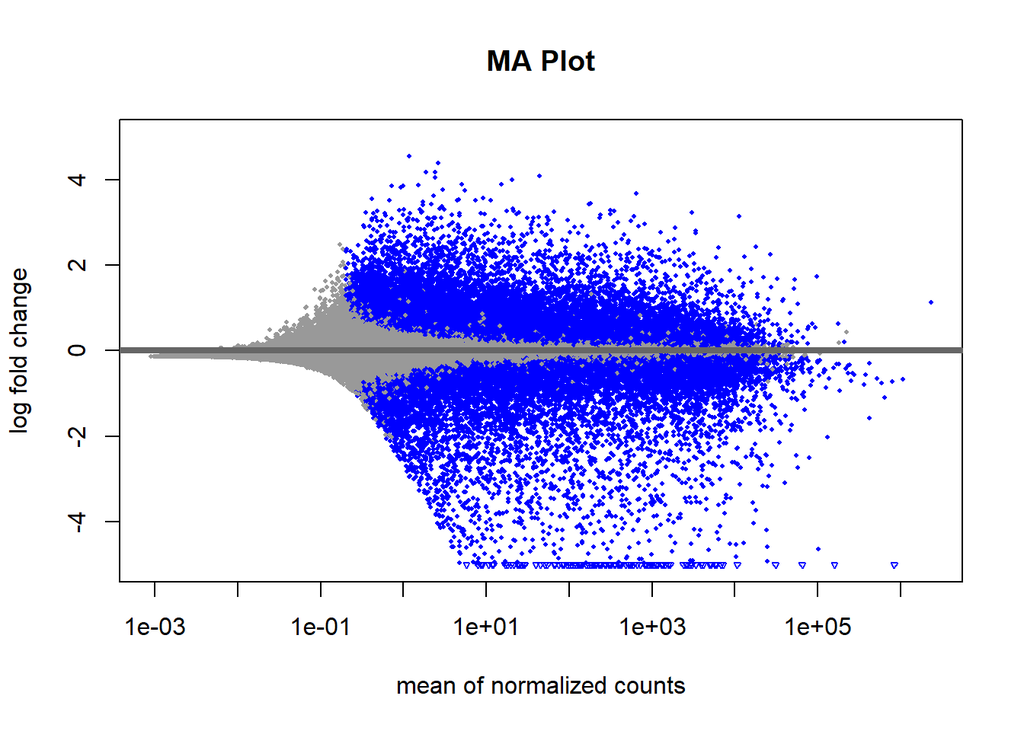

```r
plotMA(res, main = "MA Plot", ylim = c(-5, 5))
```

Neste gráfico, cada ponto representa um gene, sendo destacados aqueles que apresentam diferenças estatisticamente significativas entre amostras tumorais e normais.

O MA plot permite observar que, embora muitos genes apresentem níveis de expressão semelhantes entre os dois grupos, existe também um número significativo de genes com diferenças expressivas, tanto positivas como negativas, ao longo de diferentes níveis de expressão.

Para complementar a análise, foi utilizado um Volcano Plot, que permite visualizar simultaneamente a magnitude das alterações de expressão e a sua significância estatística.

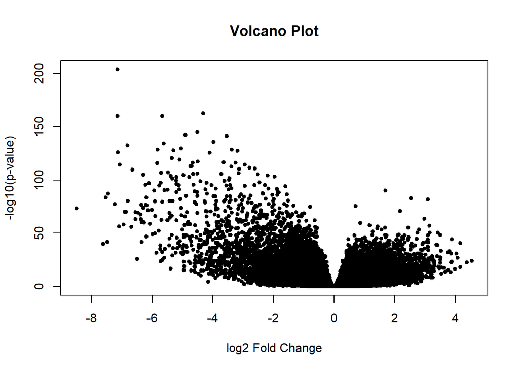

```r
plot(res$log2FoldChange,
     -log10(res$pvalue),
     pch=20,
     main="Volcano Plot",
     xlab="log2 Fold Change",
     ylab="-log10(p-value)")
```

# 5. Modelos Preditivos

Nesta secção foram construídos modelos de aprendizagem supervisionada com o objetivo de classificar as amostras em função do seu tipo, distinguindo entre tecido tumoral e tecido normal.

De acordo com os princípios da aprendizagem supervisionada, os modelos são treinados com base em exemplos previamente rotulados, permitindo posteriormente prever a classe de novas amostras.

## 5.1 Preparação dos dados

Para a construção dos modelos preditivos, foi utilizado um subconjunto dos genes mais relevantes, selecionados com base na análise de expressão diferencial.

```r
expr_ml <- expr_log
expr_ml[!is.finite(expr_ml)] <- NA

expr_ml <- expr_ml[complete.cases(expr_ml), ]

top_genes <- rownames(res)[order(res$padj)][1:50]

top_genes <- intersect(top_genes, rownames(expr_ml))

X <- t(expr_ml[top_genes, ])
y <- as.factor(meta$sample_type)
```

De forma a avaliar corretamente o desempenho dos modelos, os dados foram divididos em conjuntos de treino e teste.

```r
set.seed(123)
train_idx <- sample(1:nrow(X), 0.7*nrow(X))

X_train <- X[train_idx, ]
X_test  <- X[-train_idx, ]

y_train <- y[train_idx]
y_test  <- y[-train_idx]
```

Esta divisão permite treinar os modelos num subconjunto dos dados e avaliá-los de forma independente, evitando sobreajustamento.

## 5.2 Regressão logística

Como modelo inicial, foi utilizada regressão logística, um método clássico de classificação binária.

```r
model_log <- glm(y_train ~ ., data = as.data.frame(X_train), family = binomial)
```

Foram obtidas previsões para o conjunto de teste.

```r
pred_prob <- predict(model_log, newdata = as.data.frame(X_test), type = "response")
pred_class <- ifelse(pred_prob > 0.5, levels(y)[2], levels(y)[1])
pred_class <- as.factor(pred_class)
```

A avaliação do modelo foi realizada através da matriz de confusão.

```r
table(Predicted = pred_class, Actual = y_test)
```

```
##                      Actual
## Predicted             Primary Tumor Solid Tissue Normal
##   Primary Tumor                 145                   2
##   Solid Tissue Normal             4                  19
```

A accuracy foi calculada como a proporção de classificações corretas.

```r
mean(pred_class == y_test)
```

```
## [1] 0.9647059
```

Este modelo fornece uma baseline simples para comparação com métodos mais avançados.

## 5.3 Modelos com validação cruzada

De forma a obter uma avaliação mais robusta, foram utilizados modelos treinados com o pacote `caret`, que permite incorporar validação cruzada no processo de treino.

```r
library(caret)

ctrl <- trainControl(method = "cv", number = 5)
```

### Regressão logística

```r
model_caret_log <- train(X_train, y_train,
                         method = "glm",
                         family = "binomial",
                         trControl = ctrl)
```

### k-Nearest Neighbors (kNN)

```r
model_knn <- train(X_train, y_train,
                   method = "knn",
                   trControl = ctrl)
```

Foram obtidas previsões para o conjunto de teste.

```r
pred_log_caret <- predict(model_caret_log, X_test)
pred_knn <- predict(model_knn, X_test)
```

## 5.4 Avaliação dos modelos

A avaliação dos modelos foi realizada com base na matriz de confusão e na accuracy.

### Regressão logística (caret)

```r
table(Predicted = pred_log_caret, Actual = y_test)
```

```
##                      Actual
## Predicted             Primary Tumor Solid Tissue Normal
##   Primary Tumor                 145                   2
##   Solid Tissue Normal             4                  19
```

```r
mean(pred_log_caret == y_test)
```

```
## [1] 0.9647059
```

### kNN

```r
table(Predicted = pred_knn, Actual = y_test)
```

```
##                      Actual
## Predicted             Primary Tumor Solid Tissue Normal
##   Primary Tumor                 142                   2
##   Solid Tissue Normal             7                  19
```

```r
mean(pred_knn == y_test)
```

```
## [1] 0.9470588
```

A comparação dos resultados permite avaliar o desempenho relativo dos diferentes modelos na classificação das amostras.

De forma geral, observa-se que os modelos apresentam elevada capacidade de discriminação entre amostras tumorais e normais, refletindo a forte separação identificada nas análises anteriores.

## 5.4 Avaliação dos modelos

A avaliação dos modelos foi realizada com base na matriz de confusão e em métricas de desempenho adequadas a problemas de classificação binária, nomeadamente a accuracy, a sensibilidade e a especificidade.

A comparação entre os modelos permite avaliar diferentes abordagens de classificação. A regressão logística implementada manualmente fornece uma baseline simples, enquanto a versão implementada com o pacote `caret` incorpora validação cruzada durante o treino, permitindo uma estimativa mais robusta do desempenho.

O modelo kNN, por sua vez, baseia-se na proximidade entre amostras no espaço de características, constituindo uma abordagem não paramétrica distinta.

Dado o desbalanceamento entre as classes, com um maior número de amostras tumorais, a análise conjunta da sensibilidade e especificidade é essencial para uma avaliação mais completa do desempenho dos modelos, evitando conclusões baseadas exclusivamente na accuracy.

### Regressão logística (implementação manual)

```r
conf_log_manual <- table(Predicted = pred_class, Actual = y_test)
conf_log_manual
```

```
##                      Actual
## Predicted             Primary Tumor Solid Tissue Normal
##   Primary Tumor                 145                   2
##   Solid Tissue Normal             4                  19
```

```r
accuracy_log_manual <- mean(pred_class == y_test)

TP <- conf_log_manual[2,2]
TN <- conf_log_manual[1,1]
FP <- conf_log_manual[2,1]
FN <- conf_log_manual[1,2]

sensitivity_log_manual <- TP / (TP + FN)
specificity_log_manual <- TN / (TN + FP)

accuracy_log_manual
```

```
## [1] 0.9647059
```

```r
sensitivity_log_manual
```

```
## [1] 0.9047619
```

```r
specificity_log_manual
```

```
## [1] 0.9731544
```

### Regressão logística (caret)

```r
conf_log_caret <- table(Predicted = pred_log_caret, Actual = y_test)
conf_log_caret
```

```
##                      Actual
## Predicted             Primary Tumor Solid Tissue Normal
##   Primary Tumor                 145                   2
##   Solid Tissue Normal             4                  19
```

```r
accuracy_log_caret <- mean(pred_log_caret == y_test)

TP <- conf_log_caret[2,2]
TN <- conf_log_caret[1,1]
FP <- conf_log_caret[2,1]
FN <- conf_log_caret[1,2]

sensitivity_log_caret <- TP / (TP + FN)
specificity_log_caret <- TN / (TN + FP)

accuracy_log_caret
```

```
## [1] 0.9647059
```

```r
sensitivity_log_caret
```

```
## [1] 0.9047619
```

```r
specificity_log_caret
```

```
## [1] 0.9731544
```

### k-Nearest Neighbors (kNN)

```r
conf_knn <- table(Predicted = pred_knn, Actual = y_test)
conf_knn
```

```
##                      Actual
## Predicted             Primary Tumor Solid Tissue Normal
##   Primary Tumor                 142                   2
##   Solid Tissue Normal             7                  19
```

```r
accuracy_knn <- mean(pred_knn == y_test)

TP <- conf_knn[2,2]
TN <- conf_knn[1,1]
FP <- conf_knn[2,1]
FN <- conf_knn[1,2]

sensitivity_knn <- TP / (TP + FN)
specificity_knn <- TN / (TN + FP)

accuracy_knn
```

```
## [1] 0.9470588
```

```r
sensitivity_knn
```

```
## [1] 0.9047619
```

```r
specificity_knn
```

```
## [1] 0.9530201
```

```r
results <- data.frame(
  Model = c("Logistic (manual)", "Logistic (caret)", "kNN"),
  Accuracy = c(accuracy_log_manual, accuracy_log_caret, accuracy_knn),
  Sensitivity = c(sensitivity_log_manual, sensitivity_log_caret, sensitivity_knn),
  Specificity = c(specificity_log_manual, specificity_log_caret, specificity_knn)
)

results
```

```
##               Model  Accuracy Sensitivity Specificity
## 1 Logistic (manual) 0.9647059   0.9047619   0.9731544
## 2  Logistic (caret) 0.9647059   0.9047619   0.9731544
## 3               kNN 0.9470588   0.9047619   0.9530201
```

A comparação dos modelos revela um desempenho global elevado em todas as abordagens consideradas.

Os modelos de regressão logística, tanto na implementação manual como através do pacote `caret`, apresentam resultados praticamente idênticos, com elevada accuracy, sensibilidade e especificidade. Este resultado sugere que a validação cruzada não introduziu melhorias significativas no desempenho, indicando que o problema de classificação apresenta uma estrutura relativamente bem definida.

De forma geral, todos os modelos demonstram uma forte capacidade de discriminação entre amostras tumorais e normais, sendo os resultados consistentes com as análises exploratórias e de expressão diferencial previamente realizadas.

## Comparação entre análise diferencial e modelos preditivos

Para avaliar a consistência entre abordagens, foi comparado o conjunto de genes diferencialmente expressos com os genes mais importantes identificados pelos modelos preditivos.

```r
imp <- varImp(model_caret_log)$importance
top_de <- rownames(res)[order(res$padj)][1:50]
top_de_clean <- sub("\\..*", "", top_de)

top_ml <- rownames(imp)[order(-imp$Overall)][1:20]
top_ml_clean <- sub("\\..*", "", top_ml)

common_genes <- intersect(top_de_clean, top_ml_clean)
```

```r
common_genes
```

```
##  [1] "ENSG00000145864" "ENSG00000170439" "ENSG00000163898" "ENSG00000162873"
##  [5] "ENSG00000175832" "ENSG00000174460" "ENSG00000277363" "ENSG00000062038"
##  [9] "ENSG00000143171" "ENSG00000187583" "ENSG00000169302" "ENSG00000143217"
## [13] "ENSG00000244694" "ENSG00000158352" "ENSG00000138185" "ENSG00000115414"
## [17] "ENSG00000146267" "ENSG00000197635" "ENSG00000204131" "ENSG00000197467"
```

```r
length(common_genes)
```

```
## [1] 20
```

Observa-se uma coincidência total entre os genes mais relevantes identificados pelas duas abordagens, indicando que os genes com maior significância estatística são também aqueles que mais contribuem para a classificação das amostras.

Este resultado evidencia uma forte consistência entre métodos e sugere que a informação capturada pela análise de expressão diferencial é altamente relevante no contexto de modelos preditivos.

Adicionalmente, esta concordância reforça a evidência de que as diferenças entre amostras tumorais e normais são marcadas, permitindo uma classificação eficaz baseada num conjunto reduzido de genes.